# ahmed_ibrahim_hwfinal

# Introduction: Quiz Form

The quiz form contains 5 demographic questions and 10 covid19-related questions. I have gotten 33 responses from 17 males and 16 females. Note: If I had the chance to make an improvement on this quiz, I would add more continuous-valued demographic questions and specify the targeted population more accurately.

### Demographic Questions

**Gender** : Nominal  
**Age** : Interval  
**Residence** Location : Nominal  
**Ethnicity** : Nominal  
**Education** : Ordinal

### Quiz Questions, Answers & Response rates

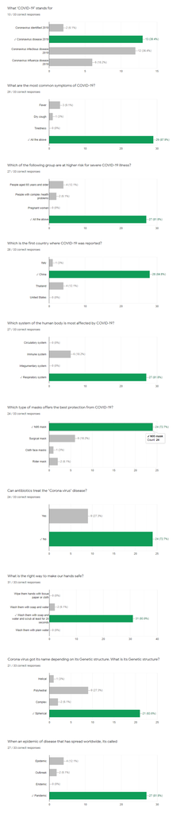

Quiz Questions

##### 1. What ‘COVID-19’ stands for

###### Number of responses: 13 / 33 correct responses.

- Coronavirus disease 2019 ( Correct )
- Coronavirus infectious disease 2019
- Coronavirus identified 2019
- Coronavirus influenza disease 2019

##### 2. What are the most common symptoms of COVID-19?.

###### Number of responses: 29 / 33 correct responses.

- Fever
- Dry cough
- Tiredness
- All the above ( Correct )

##### 3.Which of the following group are at higher risk for severe COVID-19 illness?

###### Number of responses: 27 / 33 correct responses.

- People aged 65 years and older
- People with complex health problems
- Pregnant women
- All the above ( Correct )

##### 4. Which is the first country where COVID-19 was reported?

###### Number of responses: 28 / 33 correct responses.

- Italy
- China ( Correct )
- Thailand
- United States

##### 5. Which system of the human body is most affected by COVID‑19?

###### Number of responses: 27 / 33 correct responses.

- Circulatory system
- Immune system
- Integumentary system
- Respiratory system ( Correct )

##### 6. Which type of masks offers the best protection from COVID-19?

###### Number of responses: 24 / 33 correct responses.

- N95 mask ( Correct )
- Surgical mask
- Cloth face masks
- Rider mask

##### 7. Can antibiotics treat the “Corona virus” disease?

###### Number of responses: 24 / 33 correct responses.

- Yes
- No ( Correct )

##### 8. What is the right way to make our hands safe?

###### Number of responses: 31 / 33 correct responses.

- Wipe them hands with tissue paper or cloth
- Wash them with soap and water
- Wash them with soap and water and scrub at least for 20 seconds ( Correct )
- Wash them with plain water

##### 9. Corona virus got its name depending on its Genetic structure. What is its Genetic structure?

###### Number of responses: 21 / 33 correct responses.

- Helical
- Polyhedral
- Complex
- Spherical ( Correct )

##### 10. When an epidemic of disease that has spread worldwide, its called:

###### Number of responses: 27 / 33 correct responses.

- Epidemic
- Outbreak
- Endemic
- Pandemic ( Correct )

### Importing Data and Libraries

```r
# Loading important Libraries
library(ggplot2)
library(ggpubr)

# Importing COVID-19 Awareness Champions Quiz answers dataset
covid19.data<- read.csv("covid19.csv")
attach(covid19.data)
```

```r
# Getting Important Features"Columns" from COVID19 file
columns <- c(3,5,6,7,8,9,2)
covid19.data <- covid19.data[,columns]
head(covid19.data)
```

```
##                    Name Gender             Age Residence.Location
## 1 ABDUL WARIS MOHAMMED    Male 25-34 years old               Asia
## 2                Brahim   Male 18-24 years old             Europe
## 3    Abdullah Alshibany   Male 18-24 years old             Europe
## 4    Abdullah Alihmarry   Male 18-24 years old             Europe
## 5            Khalil Ali   Male 18-24 years old             Europe
## 6          Sara Kaviani Female 35-44 years old             Europe
##                   Ethnicity                         Education Total.score
## 1 Black or African American    Bachelor's degree (e.g BA, BS)          90
## 2                     White    Bachelor's degree (e.g BA, BS)          80
## 3                     White  High school degree or equivalent          50
## 4                     White  High school degree or equivalent          90
## 5                     White  High school degree or equivalent          70
## 6                     Other Master's Degree (e.g MA, MS, MEd)          60
```

### A. Data visualization and descriptive stats

#### 1. Gender-based Data visualization

- Displaying Count of each gender using Pie-chart

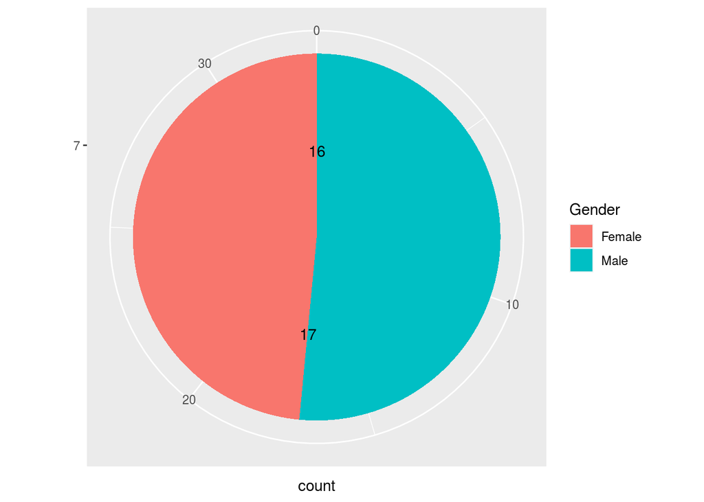

```r
ggplot(covid19.data, aes(x=factor(length(covid19.data)), fill=Gender))+
  geom_bar(width = 1)+
  coord_polar("y") + xlab(" ") + geom_text(aes(label=..count..),
              vjust=1,stat='count',
              position = "stack")
```

- Displaying the distribution of Total.score for each Gender. It shows Min,Q1,Median,Q3,MAX

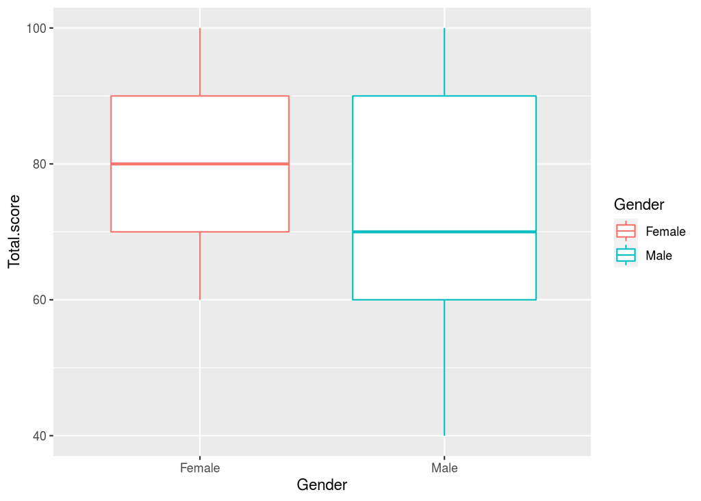

```r
ggplot(data=covid19.data, aes(x=Gender, y=Total.score, color=Gender)) + geom_boxplot(varwidth = TRUE)
```

```r
# The graph shows that : Females have better Median total.score than Males. Also, It tells that Females has narrower Interquartile range than Males.
```

#### 2. Age-based Data visualization

- Displaying Count of the People in each Age interval using bar-chart

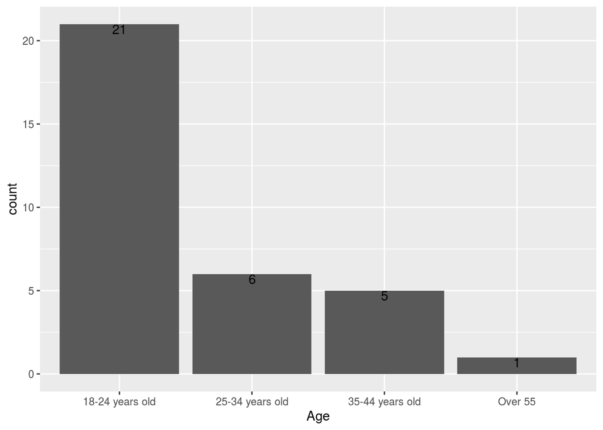

```r
ggplot(data = covid19.data ,aes(x=Age))+geom_bar() + geom_text(aes(label=..count..),
              vjust=1,stat='count',
              position = "stack")
```

- Displaying the distribution of Total.score for each Age-interval. It shows Min,Q1,Median,Q3,MAX

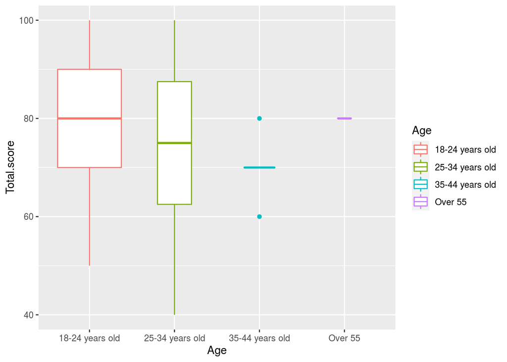

```r
ggplot(data=covid19.data, aes(x=Age, y=Total.score, color=Age)) + geom_boxplot(varwidth = TRUE)
```

```r
# Graph Description:
# Regardless of the count of records in each age interval,
# The graph shows that :
# Median(18-24 years old) = Median(Over 55 years old)
# Median(18-24 years old) > Median(25-34 years old)
# Median(25-34 years old) > Median(35-44 years old)
# Also, It tells that,
# IQR(18-24 years old) < IQR(25-34 years old)
```